# Exploratory analysis

Bin Regression

```r
# Perform a binned regression using the feols function
binned_reg = feols(LOG_VALUE~as_factor(ntile(LOG_MIGRATION,10)), data = clean_data)
# Display the summary of the regression model
summary(binned_reg)
```

```
## OLS estimation, Dep. Var.: LOG_VALUE
## Observations: 21,897
## Standard-errors: IID
##                                       Estimate Std. Error  t value  Pr(>|t|)
## (Intercept)                           3.275611   0.013264 246.9545 < 2.2e-16
## as_factor(ntile(LOG_MIGRATION, 10))2  0.356959   0.018758  19.0295 < 2.2e-16
## as_factor(ntile(LOG_MIGRATION, 10))3  0.731026   0.018758  38.9711 < 2.2e-16
## as_factor(ntile(LOG_MIGRATION, 10))4  1.112155   0.018758  59.2891 < 2.2e-16
## as_factor(ntile(LOG_MIGRATION, 10))5  1.511407   0.018758  80.5733 < 2.2e-16
## as_factor(ntile(LOG_MIGRATION, 10))6  1.924057   0.018758 102.5717 < 2.2e-16
## as_factor(ntile(LOG_MIGRATION, 10))7  2.377107   0.018758 126.7239 < 2.2e-16
## as_factor(ntile(LOG_MIGRATION, 10))8  3.010887   0.018760 160.4924 < 2.2e-16
## as_factor(ntile(LOG_MIGRATION, 10))9  3.802364   0.018760 202.6813 < 2.2e-16
## as_factor(ntile(LOG_MIGRATION, 10))10 5.083696   0.018760 270.9815 < 2.2e-16
##
## (Intercept)                           ***
## as_factor(ntile(LOG_MIGRATION, 10))2  ***
## as_factor(ntile(LOG_MIGRATION, 10))3  ***
## as_factor(ntile(LOG_MIGRATION, 10))4  ***
## as_factor(ntile(LOG_MIGRATION, 10))5  ***
## as_factor(ntile(LOG_MIGRATION, 10))6  ***
## as_factor(ntile(LOG_MIGRATION, 10))7  ***
## as_factor(ntile(LOG_MIGRATION, 10))8  ***
## as_factor(ntile(LOG_MIGRATION, 10))9  ***
## as_factor(ntile(LOG_MIGRATION, 10))10 ***
## ---
## Signif. codes:  0 '***' 0.001 '**' 0.01 '*' 0.05 '.' 0.1 ' ' 1
## RMSE: 0.620581   Adj. R2: 0.857892
```

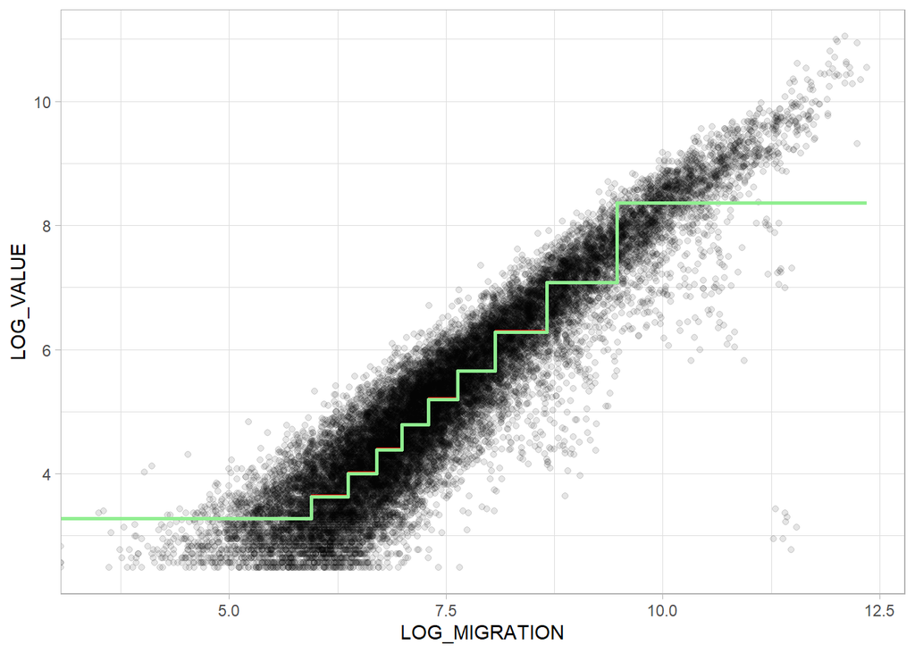

```r
# Predict values using the binned regression model and add confidence intervals
binned_reg_predict=predict(binned_reg,data=clean_data,interval = "confidence")
# Combine the original data with the predicted values and confidence intervals
binned_reg_fitted= cbind(clean_data,binned_reg_predict)

# Create a plot to visualize the binned regression fit and confidence intervals
ggplot(binned_reg_fitted,aes(x=LOG_MIGRATION))+ theme_light() +
   # Scatter plot of actual data points with low opacity
  geom_point(aes(y = LOG_VALUE), alpha = 0.1) +
   # Confidence interval ribbon around the fitted line
  geom_ribbon(aes(ymin = ci_low, ymax = ci_high), fill = "red") +
  # Fitted line from the binned regression model
  geom_line(aes(y = fit), size = 1, color = "lightgreen")
```

The scatter plot provides a clear relationship between the housing prices and migration. The dense cloud of points indicates a positive correlation between migration and housing prices. As migration increases, housing prices also tends to increase, showing a general upward trend.

Cubic Splines

```r
# Perform a piece wise cubic regression using B-splines
pw_cubic=feols(VALUE~ splines::bs(`NO_OF_INDIVIDUALS(INFLOW)`,df=5),
               clean_data)
# Display the summary of the regression model
summary(pw_cubic)
```

```
## OLS estimation, Dep. Var.: VALUE
## Observations: 21,897
## Standard-errors: IID
##                                                     Estimate Std. Error
## (Intercept)                                          27.8166    62.3207
## splines::bs(`NO_OF_INDIVIDUALS(INFLOW)`, df = 5)1   -13.0513    79.0256
## splines::bs(`NO_OF_INDIVIDUALS(INFLOW)`, df = 5)2    93.7868    61.0567
## splines::bs(`NO_OF_INDIVIDUALS(INFLOW)`, df = 5)3 13707.2647   154.5846
## splines::bs(`NO_OF_INDIVIDUALS(INFLOW)`, df = 5)4 22757.4310   414.7878
## splines::bs(`NO_OF_INDIVIDUALS(INFLOW)`, df = 5)5 49810.4744   534.9646
##                                                     t value  Pr(>|t|)
## (Intercept)                                        0.446346   0.65535
## splines::bs(`NO_OF_INDIVIDUALS(INFLOW)`, df = 5)1 -0.165153   0.86883
## splines::bs(`NO_OF_INDIVIDUALS(INFLOW)`, df = 5)2  1.536061   0.12454
## splines::bs(`NO_OF_INDIVIDUALS(INFLOW)`, df = 5)3 88.671623 < 2.2e-16 ***
## splines::bs(`NO_OF_INDIVIDUALS(INFLOW)`, df = 5)4 54.865235 < 2.2e-16 ***
## splines::bs(`NO_OF_INDIVIDUALS(INFLOW)`, df = 5)5 93.109852 < 2.2e-16 ***
## ---
## Signif. codes:  0 '***' 0.001 '**' 0.01 '*' 0.05 '.' 0.1 ' ' 1
## RMSE: 1,034.4   Adj. R2: 0.830461
```

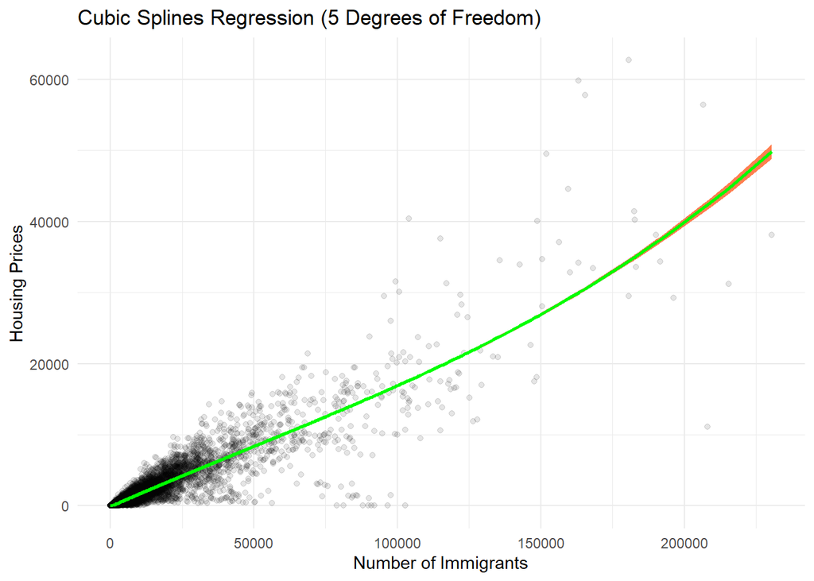

```r
# Generate fitted values for cubic splines using predict
pw_cubic_predict = predict(pw_cubic,data=clean_data, interval = "confidence")
pw_cubic_fitted=cbind(clean_data,pw_cubic_predict)

# Create a plot to visualize the piece wise cubic regression fit and confidence intervals
ggplot(pw_cubic_fitted, aes(x = `NO_OF_INDIVIDUALS(INFLOW)`)) + theme_light()+
  # Scatter plot of original data points
  geom_point(aes(y=VALUE),alpha = 0.1)+
  # Confidence interval ribbon around the fitted line
    geom_ribbon(aes(ymin = ci_low, ymax = ci_high), fill = "coral", alpha=2)+
  # Fitted line from the piece wise cubic regression model
  geom_line(aes(y =fit), size = 1,color = "green")+
  labs(x = "Number of Immigrants", y = "Housing Prices", title = "Cubic Splines Regression (5 Degrees of Freedom)") +
  theme_minimal()
```

This plot shows the relationship between the number of immigrants and housing prices, with a fitted regression line using cubic splines with 5 degrees of freedom. The spline curve shows a non-linear positive relationship between the number of immigrants and housing prices. At lower levels of immigration, housing prices rise gradually. As the number of immigrants increases, the slope of the curve becomes steeper, indicating a faster rate of increase in housing prices.This could suggest that states with higher numbers of immigrants experience higher demand for housing, leading to increased housing prices.

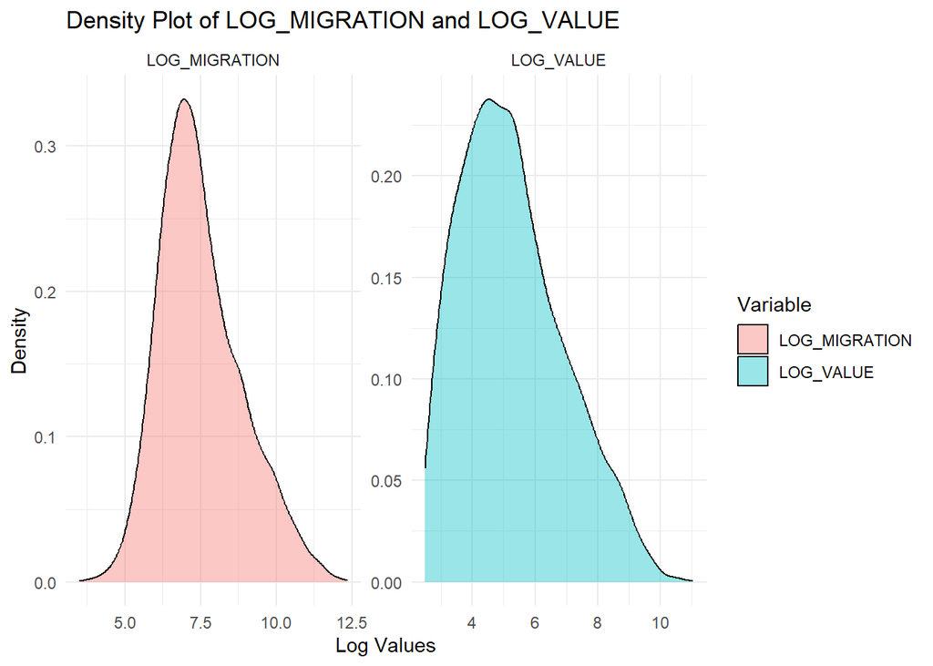

```r
# Reshape data to a long format for easier plotting of multiple variables

clean_data_long = clean_data |>
  pivot_longer(
    cols = c(LOG_MIGRATION, LOG_VALUE),# Select columns to pivot into long format
    names_to = "Variable", # Name the new column that will hold the variables names
    values_to = "Log_Value" # Name the new column that will hold the values of the variables
    )

# Plot density distributions for LOG_MIGRATION (Migration) and LOG_VALUE (Housing prices)
ggplot(clean_data_long, aes(x = Log_Value, fill = Variable)) +
# Density plot with transparency and smoother curve
  geom_density(alpha = 0.4, adjust = 1.2) +
#Adds plot title
  labs(title = "Density Plot of LOG_MIGRATION and LOG_VALUE",
       x = "Log Values",
       y = "Density") +
# Apply a minimal theme for a clear visualization
  theme_minimal() +
# Separate panels for each variable, with independent scales
  facet_wrap(~ Variable, scales = "free")  # Separate panels for each variable
```